# Drake_Zhou_Part_03_A

Drake Zhou

4/26/2022

# Oerview & Preparation

Before using advanced methods, you need to develop a baseline understanding of the event probability as a function of the inputs using generalized linear modeling techniques.

## Package import

```r
library(tidyverse)
library(caret)
library(coefplot)
library(tidymodels)
library(splines)
```

## Data import

```r
df_all <- readr::read_csv("final_project_train.csv", col_names = TRUE)
# Standardize data
standard_df_all <- df_all %>%
  select(starts_with("x")) %>%
  scale(center = TRUE, scale = TRUE) %>%
  as.data.frame() %>%
  tibble::as_tibble() %>%
  mutate(obs = if_else(df_all$outcome == 'event',1,0),
         region = factor(df_all$region, levels = c("XX", "YY", "ZZ")),
         customer = factor(df_all$customer, levels = c("A", "B", "D", "E", "G", "Other", "Q", "M", "K")))

# Resampling validation
train_id <- sample(1:nrow(standard_df_all), size = floor(0.8 * nrow(standard_df_all)))
train_ready <- standard_df_all %>% slice(train_id)
test_ready <- standard_df_all %>% slice(-train_id)
```

# Model Fitting

Use glm() to fit the following linear models: • Categorical variables only –linear additive • Continuous variables only –linear additive • All categorical and continuous variables –linear additive • Interact region with continuous inputs, do not include customer • Interact customer with continuous inputs, do not include region • All pairwise interactions of continuous inputs, do not include categorical inputs • 3 models with basis functions of your choice• Can include interactions of the basis functions with other basis functions and with the categorical inputs!

```r
# Model for categorical variables
cat_mod1 = glm(obs ~ region + customer, data = train_ready, family = binomial(link = "logit"))

# Model for continuous variables only additively &
cat_mod2 = glm(obs ~ ., data = train_ready[c(-36, -35)], family = "binomial")

# All categorical and continuous variables
cat_mod3 <- glm(obs ~ ., data = train_ready,family = "binomial")

# Interact region with continuous inputs, do not include customer
cat_mod4 <- glm(obs ~ region * ., data = train_ready[-36],family = "binomial")

# Interact customer with continuous inputs, do not include region
cat_mod5 <- glm(obs ~ customer * ., data = train_ready[-35],family = "binomial")
# All pairwise interactions of continuous inputs
cat_mod6 = glm(obs ~ (.)^2, data = train_ready[c(-36, -35)],family = "binomial")
# Model with polynomial
cat_mod7 <- glm(obs ~ poly(xb_01, 2)+poly(xb_02, 2)+ poly(xb_03,2)+poly(xn_01,2)+poly(xn_02,2)+poly(xn_03,2)+poly(xa_01,2)+poly(xa_02,2)+poly(xa_03,2)+poly(xb_04,2)+poly(xb_05,2)+poly(xb_06,2)+poly(xb_07,2)+poly(xb_08,2)+poly(xn_04,2)+poly(xn_05,2)+poly(xn_06,2)+poly(xn_07,2)+poly(xn_08,2)+poly(xa_04,2)+poly(xa_05,2)+poly(xa_06,2)+poly(xa_07,2)+poly(xa_08,2)+poly(xw_01,2)+poly(xw_02,2)+poly(xw_03,2)+poly(xs_01,2)+poly(xs_02,2)+poly(xs_03,2)+poly(xs_04,2)+poly(xs_05,2)+poly(xs_06,2)*region*customer, data = train_ready,family = "binomial")
# Model with natural spline on continuous variables
cat_mod8 <- glm(obs ~ ns(xb_01, 2)+ns(xb_02, 2)+ ns(xb_03,2)+ns(xn_01,2)+ns(xn_02,2)+ns(xn_03,2)+ns(xa_01,2)+ns(xa_02,2)+ns(xa_03,2)+ns(xb_04,2)+ns(xb_05,2)+ns(xb_06,2)+ns(xb_07,2)+ns(xb_08,2)+ns(xn_04,2)+ns(xn_05,2)+ns(xn_06,2)+ns(xn_07,2)+ns(xn_08,2)+ns(xa_04,2)+ns(xa_05,2)+ns(xa_06,2)+ns(xa_07,2)+ns(xa_08,2)+ns(xw_01,2)+ns(xw_02,2)+ns(xw_03,2)+ns(xs_01,2)+ns(xs_02,2)+ns(xs_03,2)+ns(xs_04,2)+ns(xs_05,2)+ns(xs_06,2), data = train_ready,family = "binomial")
```

```
## Warning: glm.fit: fitted probabilities numerically 0 or 1 occurred
```

```r
# Model with natural spline with higher degree of freedom
cat_mod9 <- glm(obs ~ ns(xb_01, 3)+ns(xb_03, 3)+ ns(xb_03,3)+ns(xn_01,3)+ns(xn_03,3)+ns(xn_03,3)+ns(xa_01,3)+ns(xa_03,3)+ns(xa_03,3)+ns(xb_04,3)+ns(xb_05,3)+ns(xb_06,3)+ns(xb_07,3)+ns(xb_08,3)+ns(xn_04,3)+ns(xn_05,3)+ns(xn_06,3)+ns(xn_07,3)+ns(xn_08,3)+ns(xa_04,3)+ns(xa_05,3)+ns(xa_06,3)+ns(xa_07,3)+ns(xa_08,3)+ns(xw_01,3)+ns(xw_03,3)+ns(xw_03,3)+ns(xs_01,3)+ns(xs_03,3)+ns(xs_03,3)+ns(xs_04,3)+ns(xs_05,3)+ns(xs_06,3)+region+customer, data = train_ready,family = "binomial")
```

```
## Warning: glm.fit: fitted probabilities numerically 0 or 1 occurred
```

Yes, R prints out some warning message

# Model Evaluation

## Accuracy and Kappa – Train-set split

```r
predict_and_assess <- function(mod, test_data){
  mod1_predict <- predict(mod, test_ready, type = "response")
  mod1_predict_class <- ifelse(mod1_predict > 0.50, 1, 0)
  matrix_mod1 <- confusionMatrix(as.factor(mod1_predict_class), as.factor(test_data$obs))
}

perf_mod1 <- predict_and_assess(cat_mod1, test_ready)
perf_mod2 <- predict_and_assess(cat_mod2, test_ready)
perf_mod3 <- predict_and_assess(cat_mod3, test_ready)
perf_mod4 <- predict_and_assess(cat_mod4, test_ready)
perf_mod5 <- predict_and_assess(cat_mod5, test_ready)
perf_mod6 <- predict_and_assess(cat_mod6, test_ready)
perf_mod7 <- predict_and_assess(cat_mod7, test_ready)
perf_mod8 <- predict_and_assess(cat_mod8, test_ready)
perf_mod9 <- predict_and_assess(cat_mod9, test_ready)

perf_all <- bind_rows(perf_mod1$overall,
                      perf_mod2$overall,
                      perf_mod3$overall,
                      perf_mod4$overall,
                      perf_mod5$overall,
                      perf_mod6$overall,
                      perf_mod7$overall,
                      perf_mod8$overall,
                      perf_mod9$overall) %>%
  tibble::rowid_to_column()

perf_all
```

```
## # A tibble: 9 × 8
##   rowid Accuracy    Kappa AccuracyLower AccuracyUpper AccuracyNull
##   <int>    <dbl>    <dbl>         <dbl>         <dbl>        <dbl>
## 1     1    0.787  0               0.708         0.852        0.787
## 2     2    0.824  0.342           0.749         0.884        0.787
## 3     3    0.838  0.432           0.765         0.896        0.787
## 4     4    0.743  0.261           0.661         0.814        0.787
## 5     5    0.691  0.279           0.606         0.768        0.787
## 6     6    0.566 -0.00300         0.479         0.651        0.787
## 7     7    0.75   0.291           0.669         0.820        0.787
## 8     8    0.801  0.333           0.724         0.865        0.787
## 9     9    0.706  0.185           0.622         0.781        0.787
## # … with 2 more variables: AccuracyPValue <dbl>, McnemarPValue <dbl>
```

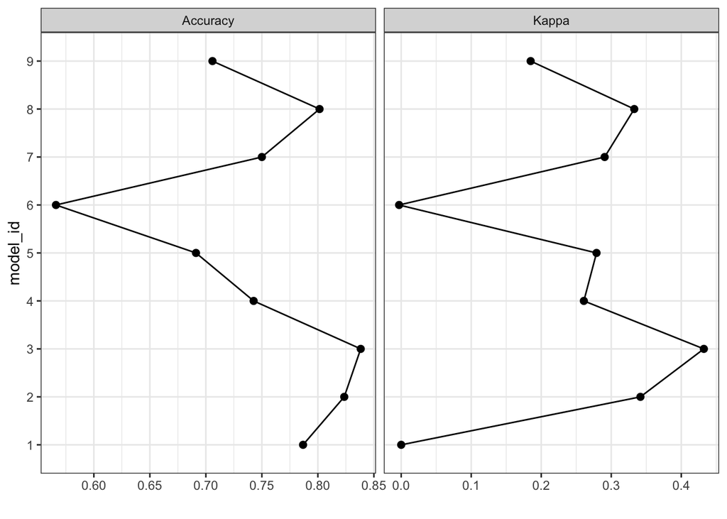

```r
perf_all %>%
  select(rowid, Accuracy, Kappa) %>%
  pivot_longer(-c("rowid")) %>%
  mutate(model_id = stringr::str_extract(rowid, "\\d+")) %>%
  ggplot(mapping = aes(y = model_id, x = value, group = 1))+
  geom_path()+
  geom_point(size = 2.0)+
  facet_grid(~name, scales = "free_x")+
  labs(x = '')+
  theme_bw()
```

## Sensitivity, Precision and Specificity – Train-set split

```r
perf_all_spec <- bind_rows(perf_mod1$byClass,
                          perf_mod2$byClass,
                          perf_mod3$byClass,
                          perf_mod4$byClass,
                          perf_mod5$byClass,
                          perf_mod6$byClass,
                          perf_mod7$byClass,
                          perf_mod8$byClass,
                          perf_mod9$byClass) %>%
  tibble::rowid_to_column()

perf_all_spec
```

```
## # A tibble: 9 × 12
##   rowid Sensitivity Specificity `Pos Pred Value` `Neg Pred Value` Precision
##   <int>       <dbl>       <dbl>            <dbl>            <dbl>     <dbl>
## 1     1       1           0                0.787          NaN         0.787
## 2     2       0.963       0.310            0.837            0.692     0.837
## 3     3       0.953       0.414            0.857            0.706     0.857
## 4     4       0.822       0.448            0.846            0.406     0.846
## 5     5       0.701       0.655            0.882            0.373     0.882
## 6     6       0.617       0.379            0.786            0.212     0.786
## 7     7       0.822       0.483            0.854            0.424     0.854
## 8     8       0.916       0.379            0.845            0.55      0.845
## 9     9       0.785       0.414            0.832            0.343     0.832
## # … with 6 more variables: Recall <dbl>, F1 <dbl>, Prevalence <dbl>,
## #   `Detection Rate` <dbl>, `Detection Prevalence` <dbl>,
## #   `Balanced Accuracy` <dbl>
```

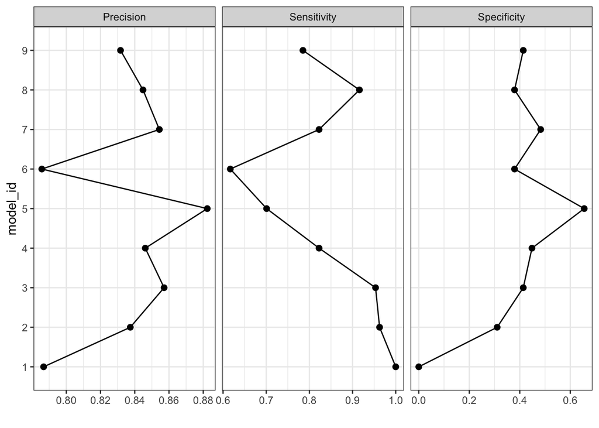

```r
perf_all_spec %>%
  select(rowid, Sensitivity, Precision, Specificity) %>%
  pivot_longer(-c("rowid")) %>%
  mutate(model_id = stringr::str_extract(rowid, "\\d+")) %>%
  ggplot(mapping = aes(y = model_id, x = value, group = 1))+
  geom_path()+
  geom_point(size = 2.0)+
  facet_grid(~name, scales = "free_x")+
  labs(x = '')+
  theme_bw()
```

```r
p1 <- broom::glance(cat_mod1)
p2 <- broom::glance(cat_mod2)
p3 <- broom::glance(cat_mod3)
p4 <- broom::glance(cat_mod4)
p5 <- broom::glance(cat_mod5)
p6 <- broom::glance(cat_mod6)
p7 <- broom::glance(cat_mod7)
p8 <- broom::glance(cat_mod8)
p9 <- broom::glance(cat_mod9)

p_all <- rbind(p1,p2,p3,p4,p5,p6,p7,p8,p9) %>%
  tibble::rowid_to_column()

p_all
```

```
## # A tibble: 9 × 9
##   rowid null.deviance df.null   logLik   AIC   BIC deviance df.residual  nobs
##   <int>         <dbl>   <int>    <dbl> <dbl> <dbl>    <dbl>       <int> <int>
## 1     1          512.     540 -2.41e+2  504.  551.  4.82e+2         530   541
## 2     2          512.     540 -1.65e+2  398.  544.  3.30e+2         507   541
## 3     3          512.     540 -1.51e+2  391.  580.  3.03e+2         497   541
## 4     4          512.     540 -1.30e+2  465.  902.  2.61e+2         439   541
## 5     5          512.     540 -1.77e+3 4092. 5294.  3.53e+3         261   541
## 6     6          512.     540 -1.96e-9  996. 3134.  3.93e-9          43   541
## 7     7          512.     540 -2.58e+2  733. 1201.  5.15e+2         432   541
## 8     8          512.     540 -1.40e+2  415.  702.  2.81e+2         474   541
## 9     9          512.     540 -9.52e+1  380.  788.  1.90e+2         446   541
```

## Deviance

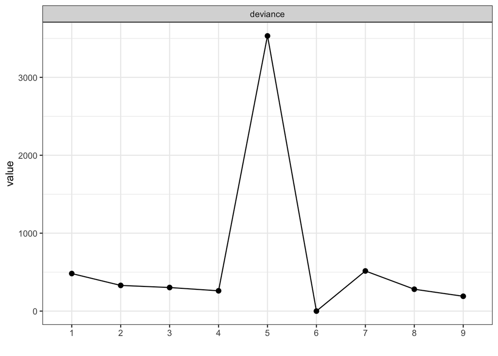

```r
p_all %>%
  select(deviance, rowid) %>%
  pivot_longer(-c("rowid")) %>%
  mutate(model_id = stringr::str_extract(rowid, "\\d+")) %>%
  ggplot(mapping = aes(x = model_id, y = value, group = 1))+
  geom_path()+
  geom_point(size = 2.0)+
  facet_grid(~name, scales = "free")+
  labs(x = '')+
  theme_bw()
```

## AIC & BIC

AIC and BIC are information criterion metrics, hence we want to minimize them which represent a better model.

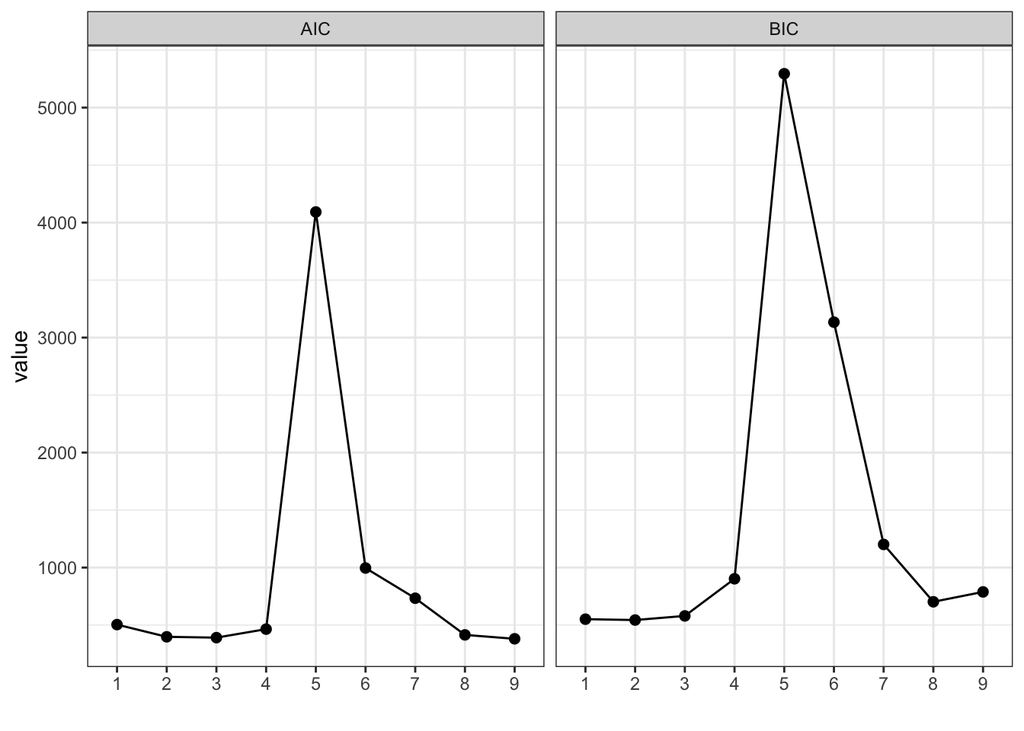

```r
p_all %>%
  select(AIC, BIC, rowid) %>%
  pivot_longer(-c("rowid")) %>%
  mutate(model_id = stringr::str_extract(rowid, "\\d+")) %>%
  ggplot(mapping = aes(x = model_id, y = value, group = 1))+
  geom_path()+
  geom_point(size = 2.0)+
  facet_grid(~name, scales = "free")+
  labs(x = '')+
  theme_bw()
```

# Conclusion

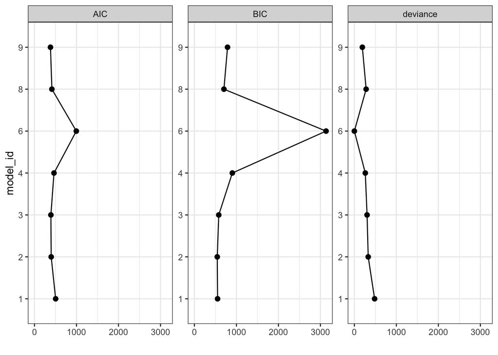

```r
p_all_selec <- rbind(p1,p2,p3,p4,p6,p8,p9) %>%
  mutate(model_id = c(1,2,3,4,6,8,9))

p_all_selec %>%
  select(model_id, deviance, AIC, BIC) %>%
  pivot_longer(-c("model_id")) %>%
  mutate(model_id = stringr::str_extract(model_id, "\\d+")) %>%
  ggplot(mapping = aes(y = model_id, x = value, group = 1))+
  geom_path()+
  geom_point(size = 2.0)+
  facet_wrap(~name, scales = "free_y")+
  labs(x = '')+
  theme_bw()
```

Which of the 9 models is the best? What performance metric did you use to make your selection?

[output not shown]

# Coefficient inspection

Visualize the coefficient summaries for your top 3 models. How do the coefficient summaries compare between the top 3?

## Model #3

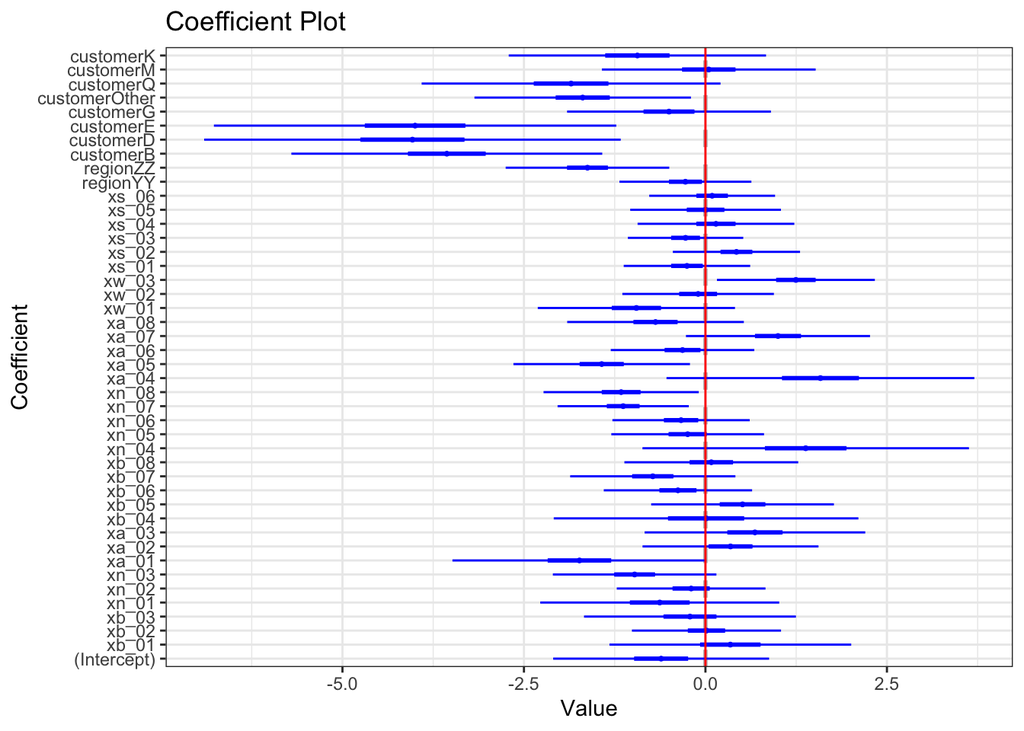

```r
cat_mod3 %>%
  coefplot(scales = "free", sort = "natural", pointSize = 1, innerCI = 0.5)+
  geom_vline(xintercept = 0, color = "red")+
  theme_bw()+
  theme(legend.position = 'none')
```

## Model #9

In model #9, if we zoom in, there are several features that are significantly important, which means 0 is not contained in their confidence interval. There are several significantly important features.

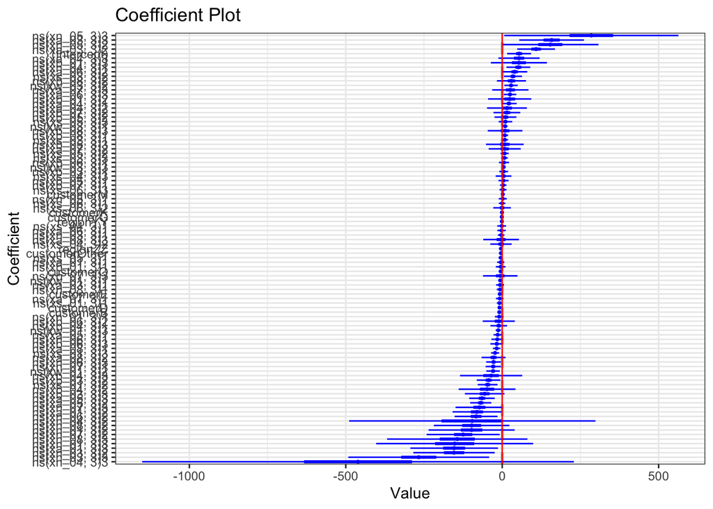

```r
cat_mod9 %>%
  coefplot(scales = "free", sort = "magnitude", pointSize = 1, innerCI = 0.5)+
  geom_vline(xintercept = 0, color = "red")+
  theme_bw()+
  theme(legend.position = 'none')
```

## Model #4

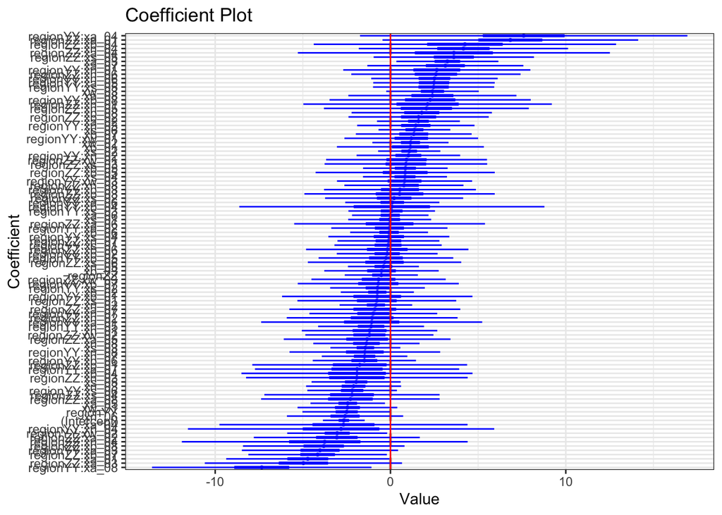

```r
cat_mod4 %>%
  coefplot(scales = "free", sort = "magnitude", pointSize = 1, innerCI = 0.5)+
  geom_vline(xintercept = 0, color = "red")+
  theme_bw()+
  theme(legend.position = 'none')
```

# Variable importance

Which input is important?

## Model #3

```r
import_input_mod3 <- cat_mod3 %>%
  coefplot(sort = "magnitude", plot = FALSE) %>%
  tibble::as_tibble() %>%
  filter((HighOuter > 0 & LowOuter > 0) | (HighOuter < 0 & LowOuter < 0))

head(import_input_mod3)
```

```
## # A tibble: 6 × 7
##   Value Coefficient   HighInner LowInner HighOuter LowOuter Model
##   <dbl> <fct>             <dbl>    <dbl>     <dbl>    <dbl> <chr>
## 1 -4.04 customerD        -2.60     -5.47    -1.17     -6.90 model
## 2 -4.00 customerE        -2.61     -5.39    -1.23     -6.77 model
## 3 -3.56 customerB        -2.49     -4.63    -1.42     -5.70 model
## 4 -1.69 customerOther    -0.945    -2.44    -0.200    -3.18 model
## 5 -1.62 regionZZ         -1.06     -2.19    -0.498    -2.75 model
## 6 -1.43 xa_05            -0.821    -2.04    -0.213    -2.64 model
```

## Model #9

```r
import_input_mod9 <- cat_mod9 %>%
  coefplot(sort = "magnitude", plot = FALSE) %>%
  tibble::as_tibble() %>%
  filter((HighOuter > 0 & LowOuter > 0) | (HighOuter < 0 & LowOuter < 0))

head(import_input_mod9)
```

```
## # A tibble: 6 × 7
##    Value Coefficient   HighInner LowInner HighOuter LowOuter Model
##    <dbl> <fct>             <dbl>    <dbl>     <dbl>    <dbl> <chr>
## 1 -267.  ns(xn_03, 3)3    -154.     -379.    -41.7     -492. model
## 2 -154.  ns(xn_03, 3)2     -89.1    -219.    -24.1     -284. model
## 3 -154.  ns(xa_01, 3)3     -83.8    -224.    -13.8     -294. model
## 4 -125.  ns(xn_07, 3)2     -66.4    -183.     -8.02    -242. model
## 5  -83.5 ns(xn_06, 3)2     -49.2    -118.    -14.9     -152. model
## 6  -80.8 ns(xa_01, 3)2     -41.9    -120.     -2.97    -159. model
```

## Model #4

```r
import_input_mod4 <- cat_mod4 %>%
  coefplot(sort = "magnitude", plot = FALSE) %>%
  tibble::as_tibble() %>%
  filter((HighOuter > 0 & LowOuter > 0) | (HighOuter < 0 & LowOuter < 0))

head(import_input_mod4)
```

```
## # A tibble: 6 × 7
##   Value Coefficient    HighInner LowInner HighOuter LowOuter Model
##   <dbl> <fct>              <dbl>    <dbl>     <dbl>    <dbl> <chr>
## 1 -7.34 regionYY:xa_08     -4.21   -10.5    -1.08     -13.6  model
## 2 -4.72 xa_01              -2.39    -7.04   -0.0646    -9.37 model
## 3 -4.16 regionZZ:xb_07     -2.18    -6.13   -0.206     -8.11 model
## 4 -3.04 regionYY:xw_02     -1.62    -4.47   -0.190     -5.89 model
## 5 -2.66 (Intercept)        -2.06    -3.26   -1.47      -3.85 model
## 6 -2.44 xa_05              -1.38    -3.50   -0.316     -4.56 model
```

# Export models

```r
cat_mod9 %>% readr::write_rds('models/cat_mod9.rds')
cat_mod3 %>% readr::write_rds('models/cat_mod3.rds')
cat_mod4 %>% readr::write_rds('models/cat_mod4.rds')
```